# PASIAS CHapter 9 - The sign test

Mohammad Amr Khan

**Will only contains questions 1 - 3**

## Packages

```r
library(tidyverse)
```

## Running a maze

```r
myurl <- "http://www.utsc.utoronto.ca/~butler/c32/maze.txt"
times <- read_delim(myurl, " ")
```

```r
times
```

| time |
| --- |
| 38.4 |
| 46.2 |
| 62.5 |
| 38.0 |
| 62.8 |
| 33.9 |
| 50.4 |
| 35.0 |
| 52.8 |
| 60.1 |

[output cut: 11 more lines]

**Manual Sign test**

```r
times %>% count(time > 60)
```

| time > 60 | n |
| --- | --- |
| FALSE | 16 |
| TRUE | 5 |

```r
p <- sum(dbinom(0:5, 21, 0.5))
p
```

```
[1] 0.01330185
```

```r
sum(dbinom(16:21, 21, 0.5))
```

```
[1] 0.01330185
```

since we want to the two sided p val

```r
2*p
```

```
[1] 0.0266037
```

*Using SMMR*

```r
install.packages("devtools")
```

|  | binary | source | needs_compilation |
| --- | --- | --- | --- |
| cachem | 1.0.1 | 1.0.2 | TRUE |

[output not shown]

[output not shown]

```r
library(devtools)
```

```r
install_github("nxskok/smmr")
```

```
Downloading GitHub repo nxskok/smmr@HEAD
```

[output not shown]

[output not shown]

[output not shown]

```r
library(smmr)
```

```r
sign_test(times, time, 60)
```

```
$above_below
below above
   16     5

$p_values
```

| alternative | p_value |
| --- | --- |
| lower | 0.01330185 |
| upper | 0.99640131 |
| two-sided | 0.02660370 |

```
NA
```

two-sided is 0.0266

```r
pval_sign(60, times, time)
```

```
[1] 0.0266037
```

Gives the two sided p-value

to get the confidence interval

```r
ci_median(times, time)
```

```
[1] 44.30747 57.59766
```

## Chocolate Chips

A famous cookie manufacturer claims that their bags of chocolate chip cookies contain “more than 1100 chocolate chips on average”. A diligent group of students buys 16 bags of these cookies and counts the number of chocolate chips in each bag. The results are in http://www.utsc.utoronto.ca/~butler/c32/chips.txt.

Single column so any method of reading will work

```r
chip_url <- "https://www.utsc.utoronto.ca/~butler/c32/chips.txt"
chip_data <- read_table(chip_url)
```

```r
chip_data
```

| chips |
| --- |
| 1219 |
| 1214 |
| 1087 |
| 1200 |
| 1419 |
| 1121 |
| 1325 |
| 1345 |
| 1244 |
| 1258 |

[output cut: 6 more lines]

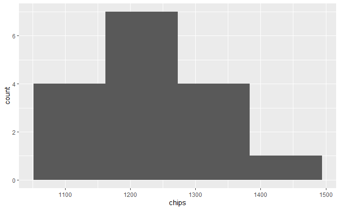

```r
ggplot(chip_data, aes(x=chips)) + geom_histogram(bins = 4)
```

Right skew

```r
chip_data %>% count(chips < 1100)
```

| chips < 1100 | n |
| --- | --- |
| FALSE | 15 |
| TRUE | 1 |

one less than 1100.

```r
chip_data %>% mutate(less=(chips<1100)) %>% count(less)
```

| less | n |
| --- | --- |
| FALSE | 15 |
| TRUE | 1 |

```r
sign_test(chip_data, chips, 1100)
```

```
$above_below
below above
    1    15

$p_values
```

| alternative | p_value |
| --- | --- |
| lower | 0.9999847412 |
| upper | 0.0002593994 |
| two-sided | 0.0005187988 |

```
NA
```

We reject null hypothesis.

```r
ci_median(chip_data, chips)
```

```
[1] 1135.003 1324.996
```

## The Power of the Sign Test

```r
power.t.test(n=10, delta = 50 -40, sd = 15, type = "one.sample")
```

```
     One-sample t test power calculation

              n = 10
          delta = 10
             sd = 15
      sig.level = 0.05
          power = 0.4691805
    alternative = two.sided
```

Power of 50%.

```r
x=rnorm(10,50,15)
x
```

```
 [1] 50.82178 63.10519 57.01826 42.07266 61.96851 39.73397 53.88227 41.97596 38.39649 17.89890
```

```r
tibble(x) %>% count(x<40)
```

| x < 40 | n |
| --- | --- |
| FALSE | 7 |
| TRUE | 3 |